# 13: Application II

#### Computing summary statistics

You have point estimates for the GPP, but rasters of NDVI as predictors. A good idea would be to compute summary statistics of the rasters, that can be turned into predictors to be further fed into the statistical model.

- Think of four different summary statistics that you can compute from the data. Build a loop, that goes through each file of `ndvi_files`, and fills in 4 lists containing each of the summary statistics, for each of those files.

```r
# get all the relevant ndvi files names in one place:

# Specify the folder path for NDVI files
ndvi_folder_og <- "./data/ndvi"
ndvi_folder_crop <- "./data/cropped_ndvi"
ndvi_folder_resize <- "./data/resize_ndvi"

# List NDVI files
ndvi_files_og <- list.files(path = ndvi_folder_og, full.names = TRUE)
ndvi_files_crop <- list.files(path = ndvi_folder_crop, full.names = TRUE)
ndvi_files_resize <- list.files(path = ndvi_folder_resize, full.names = TRUE)
```

**Hint:** Make sure to keep only the rasters which have more than 40% healthy pixels.

```r
# i do all the rest of the calculations for the ones with >40% healthy pixels only
# Loop through each NDVI file
get_summary_stats_df <- function(used_files) {
  # Initialize lists to store summary statistics and file names
  mean_values <- list()
  sd_values <- list()
  skewness_values <- list()
  kurtosis_values <- list()
  file_names <- character()
  for (j in seq_along(used_files)) {
    # Read the NDVI file
    ndvi_data <- readRDS(used_files[j])
    ndvi_matrix <- matrix(unlist(ndvi_data), nrow = DIM_RASTER, ncol = DIM_RASTER, byrow = TRUE)

    # Compute summary statistics
    mean_values[[j]] <- mean(ndvi_matrix, na.rm = TRUE)
    sd_values[[j]] <- sd(ndvi_matrix, na.rm = TRUE)
    skewness_values[[j]] <- e1071::skewness(ndvi_matrix, na.rm = TRUE)
    kurtosis_values[[j]] <- e1071::kurtosis(ndvi_matrix, na.rm = TRUE)

    # Store the file name
    file_names[j] <- used_files[j]
  }

  # Convert lists to data frames
  mean_df <- data.frame(matrix(unlist(mean_values), nrow = length(mean_values), byrow = TRUE))
  sd_df <- data.frame(matrix(unlist(sd_values), nrow = length(sd_values), byrow = TRUE))
  skewness_df <- data.frame(matrix(unlist(skewness_values), nrow = length(skewness_values), byrow = TRUE))
  kurtosis_df <- data.frame(matrix(unlist(kurtosis_values), nrow = length(kurtosis_values), byrow = TRUE))

  # Set column names
  colnames(mean_df) <- paste0("Mean_", seq_len(ncol(mean_df)))
  colnames(sd_df) <- paste0("SD_", seq_len(ncol(sd_df)))
  colnames(skewness_df) <- paste0("Skewness_", seq_len(ncol(skewness_df)))
  colnames(kurtosis_df) <- paste0("Kurtosis_", seq_len(ncol(kurtosis_df)))

  # Combine all summary statistics into one data frame
  summary_statistics_df <- cbind(file_name = file_names, mean_df, sd_df, skewness_df, kurtosis_df)

  return(summary_statistics_df)
}


# Print the summary statistics data frame
crop_summary_stats_df <- get_summary_stats_df(ndvi_files_crop)
resize_summary_stats_df <- get_summary_stats_df(ndvi_files_resize)
og_summary_stats_df <- get_summary_stats_df(ndvi_files_og)
```

- Check the dimensions of the stats dataframes

```r
dim(crop_summary_stats_df)
```

```
## [1] 4954    5
```

```r
dim(resize_summary_stats_df)
```

```
## [1] 4954    5
```

```r
dim(og_summary_stats_df)
```

```
## [1] 5617    5
```

```r
colnames(flux_data)
```

```
##  [1] "X"                    "sitename"             "year"
##  [4] "month"                "y"                    "fpar_loess_per_month"
##  [7] "TA_F_per_month"       "SW_IN_F_per_month"    "LW_IN_F_per_month"
## [10] "VPD_F_per_month"      "PA_F_per_month"       "P_F_per_month"
## [13] "WS_F_per_month"       "CO2_F_MDS_per_month"
```

```r
head(flux_data)
```

```
##   X sitename year month         y fpar_loess_per_month TA_F_per_month
## 1 1   AR-Vir 2010     2 18.155930            0.7175273       27.90639
## 2 2   AR-Vir 2010     3 16.566188            0.8062719       25.88332
## 3 3   AR-Vir 2010     4 11.883871            0.8253712       21.08527
## 4 4   AR-Vir 2010     5  7.550117            0.7912010       17.02619
## 5 5   AR-Vir 2010     9 12.171233            0.6176354       19.77360
## 6 6   AR-Vir 2010    10 12.463795            0.7283527       20.05271
##   SW_IN_F_per_month LW_IN_F_per_month VPD_F_per_month PA_F_per_month
## 1          230.0684          412.0384       13.867857       99.57232
## 2          212.2040          391.1563       11.892645       99.74226
## 3          168.1141          359.2931        9.315033      100.19970
## 4          109.3910          349.3595        5.616355      100.30897
## 5          176.7665          349.7738        6.618600      100.01453
## 6          236.9492          348.2435        6.848935      100.02084
##   P_F_per_month WS_F_per_month CO2_F_MDS_per_month
## 1      4.796929       2.778643            424.0304
## 2      6.909194       2.407871            430.5104
## 3      4.921133       2.639733            420.3460
## 4      3.307871       2.397226            432.3273
## 5      5.868133       2.339433            426.6124
## 6      3.709258       2.558194            417.1832
```

- Build a dataframe `df_data`, that contains the predictors, as well as the response variable GPP. Scale both the predictors and response variables.

```r
# create dataframe
df_data <- data.frame(flux_data_filtered[,-c(1:4)])

# scaling the data, excluding the first column which contains the locations
df_data_scaled <- as.data.frame(scale(df_data))
print(head(df_data))
```

```
##           y fpar_loess_per_month TA_F_per_month SW_IN_F_per_month
## 1 18.155930            0.7175273       27.90639          230.0684
## 2 16.566188            0.8062719       25.88332          212.2040
## 3 11.883871            0.8253712       21.08527          168.1141
## 4  7.550117            0.7912010       17.02619          109.3910
## 5 12.171233            0.6176354       19.77360          176.7665
## 6 12.463795            0.7283527       20.05271          236.9492
##   LW_IN_F_per_month VPD_F_per_month PA_F_per_month P_F_per_month WS_F_per_month
## 1          412.0384       13.867857       99.57232      4.796929       2.778643
## 2          391.1563       11.892645       99.74226      6.909194       2.407871
## 3          359.2931        9.315033      100.19970      4.921133       2.639733
## 4          349.3595        5.616355      100.30897      3.307871       2.397226
## 5          349.7738        6.618600      100.01453      5.868133       2.339433
## 6          348.2435        6.848935      100.02084      3.709258       2.558194
##   CO2_F_MDS_per_month
## 1            424.0304
## 2            430.5104
## 3            420.3460
## 4            432.3273
## 5            426.6124
## 6            417.1832
```

Alright, that’s it with the data! Let’s now start with the interesting bit.

### Linear model

We first build a linear model of the form
$$y_{GPP}= f(x_{NDVI})= W x_{NDVI}+ B$$
where $x_{NDVI}$ is the NDVI based vector of predictors.

#### Standard fit

Use the function `lm` to build a linear model, and fit it with `df_data`. - Measure the time required to fit the model. - Print a summary of the fit. - Which predictor has the strongest effect on GPP? Do all the predictors have a significant effect on the response variable?

```r
# fit the model
response_variable <- names(df_data)[1]

# fit the model
start_time <- Sys.time()
my_lm_model <- lm(paste(response_variable, "~ ."), data = df_data_scaled)
end_time <- Sys.time()
lm_training_time <- difftime(end_time, start_time, units = "mins")
df_data_scaled$sitename <- flux_data_filtered$sitename
# Print summary of the fit
summary(my_lm_model)
```

```
##
## Call:
## lm(formula = paste(response_variable, "~ ."), data = df_data_scaled)
##
## Residuals:
##      Min       1Q   Median       3Q      Max
## -1.67740 -0.31668 -0.03314  0.25652  2.95211
##
## Coefficients:
##                        Estimate Std. Error t value Pr(>|t|)
## (Intercept)          -0.0117083  0.0080561  -1.453  0.14620
## fpar_loess_per_month  0.5030580  0.0113872  44.178  < 2e-16 ***
## TA_F_per_month        0.0136495  0.0318030   0.429  0.66781
## SW_IN_F_per_month     0.4943825  0.0148873  33.208  < 2e-16 ***
## LW_IN_F_per_month     0.2782999  0.0210792  13.203  < 2e-16 ***
## VPD_F_per_month      -0.4365456  0.0194086 -22.492  < 2e-16 ***
## PA_F_per_month       -0.0718686  0.0096371  -7.458 1.06e-13 ***
## P_F_per_month         0.0340985  0.0094456   3.610  0.00031 ***
## WS_F_per_month        0.0194350  0.0085974   2.261  0.02384 *
## CO2_F_MDS_per_month  -0.0009473  0.0084873  -0.112  0.91113
## ---
## Signif. codes:  0 '***' 0.001 '**' 0.01 '*' 0.05 '.' 0.1 ' ' 1
##
## Residual standard error: 0.5231 on 4276 degrees of freedom
##   (668 observations deleted due to missingness)
## Multiple R-squared:  0.7279, Adjusted R-squared:  0.7274
## F-statistic:  1271 on 9 and 4276 DF,  p-value: < 2.2e-16
```

```r
cat("LM training time", as.numeric(lm_training_time), "mins")
```

```
## LM training time 0.0002182484 mins
```

- Extract the R2 score of the model and store it in a variable. We will need it later on.

```r
# Extract the R-squared score of the model
lm_r_squared <- summary(my_lm_model)$r.squared

# Store the R-squared score in a variable
cat("R-squared:", lm_r_squared, "\n")
```

```
## R-squared: 0.7279263
```

#### Cross validation

Our goal is to build a model that generalizes, to spatially upscale the GPP measurements. We should therefore perform a cross validation of our model, to make sure that the relationships it captures generalize well. For this, we propose to perform a k-fold cross validation:

“*In k-fold cross-validation, the original sample is randomly partitioned into k equal sized subsamples. Of the k subsamples, a single subsample is retained as the validation data for testing the model, and the remaining k − 1 subsamples are used as training data. The cross-validation process is then repeated k times, with each of the k subsamples used exactly once as the validation data. The k results can then be averaged to produce a single estimation.*” (source: Wikipedia)

- Write a loop that excludes, at each iteration, 10 of the sites, and evaluate the mean squared error (MSE) on the excluded sites. For each iteration, store the MSE in a list, and finally evaluate the model performance by printing the mean MSE obtained on the out of sample data (cross validation MSE). Store this value in a variable.

```r
#look at the sites
length(unique(flux_data_filtered[,"sitename"]))
```

```
## [1] 71
```

```r
flux_independent_variables <- c("fpar_loess_per_month","TA_F_per_month","SW_IN_F_per_month","LW_IN_F_per_month",
                              "VPD_F_per_month","PA_F_per_month","P_F_per_month", "WS_F_per_month","CO2_F_MDS_per_month")
flux_dependent_variables <- "y"
```

**Hint:** You can use the function `cut` to generate the indices of the subsamples to be excluded, at each iteration.

```r
#create folds data and check
train_sitenames_count <- 61
k <- 10 #folds
mse_per_fold <- list()

for (i in 1:k){
  train_sitenames <- sample(unique(df_data_scaled$sitename), train_sitenames_count)
  test_sitenames <- setdiff(unique(df_data_scaled$sitename), train_sitenames)
  df_train <- df_data_scaled[df_data_scaled$sitename %in% train_sitenames, ]
  df_test <- df_data_scaled[df_data_scaled$sitename %in% test_sitenames, ]
  my_lm_model_cv <- lm(formula(paste(flux_dependent_variables, "~", paste(flux_independent_variables, collapse = "+"))), data = df_train)
  pred <- predict(my_lm_model_cv, newdata = df_test)
  mse <- mean((df_test$y - pred)^2, na.rm = TRUE)
  mse_per_fold[[i]] <- mse
  cat(paste("Fold", i, "MSE:", mse, "\n"))
}
```

```
## Fold 1 MSE: 0.30223608200204
## Fold 2 MSE: 0.426450030411812
## Fold 3 MSE: 0.302145982626328
## Fold 4 MSE: 0.344966772625332
## Fold 5 MSE: 0.311468716904311
## Fold 6 MSE: 0.227224699158586
## Fold 7 MSE: 0.194507602692181
## Fold 8 MSE: 0.290590873753492
## Fold 9 MSE: 0.287237078883339
## Fold 10 MSE: 0.388680815863912
```

```r
# Calculate the mean MSE across all folds
cv_mse_lm <- mean(unlist(mse_per_fold), na.rm = TRUE)
cat(paste("\n", "CV MSE:", cv_mse_lm, "\n"))
```

```
##
##  CV MSE: 0.307550865492133
```

```r
#setequal(unique(df_data_scaled$sitename), c(train_sitenames, test_sitenames))
```

### Feed forward neural network

We now turn to a solution involving a feed forward neural network. We use the Keras library.

```r
## Loading the required libraries
library(keras) # Python library for deep learning
```

- Define a function `init_net()` that returns a neural network. The neural network shoud consist of
  - an input layer, with dimensions the number of features x,
  - a hidden layer `layer_dense`, with relu activation, with a size of 10,
  - a hidden layer `layer_dense`, with relu activation, with a size of 5,
  - an ouput layer, of size 1 with linear activation. The function `init_net()` should return a compiled neural network, using the Adam optimizer, with a learning rate `lr=0.01`.

```r
# FFNN
init_net <- function() {
  my_nn_model <- keras_model_sequential()
  my_nn_model %>%
    layer_dense(units = 10, activation = 'relu', input_shape = ncol(df_data) - 1) %>%
    layer_dense(units = 5, activation = 'relu') %>%
    layer_dense(units = 1, activation = 'linear')

  # Optimizer
  opt <- optimizer_adam(learning_rate = 0.01)

  # Compile
  compile(my_nn_model, loss = 'mse', optimizer = opt)

  my_nn_model
}
```

#### Standard fit

With the function `init_net()`, define a neural network `my_nn_model` and use `df_data` to train `my_nn_model`:

- use a batch size of 512,
- train the neural network over 100 epochs,
- measure the time required to fit the model,
- plot the training history, to make sure that the training went smoothly,
- compute the R2 of the trained neural network, and store it for later on.

```r
any_na <- any(is.na(df_data_scaled))
print(any_na)
```

```
## [1] TRUE
```

```r
print(colSums(is.na(df_data_scaled)))
```

```
##                    y fpar_loess_per_month       TA_F_per_month
##                    0                  597                    0
##    SW_IN_F_per_month    LW_IN_F_per_month      VPD_F_per_month
##                    0                    0                    0
##       PA_F_per_month        P_F_per_month       WS_F_per_month
##                    0                    0                    0
##  CO2_F_MDS_per_month             sitename
##                   72                    0
```

```r
df_data_scaled_no_na <- na.omit(df_data_scaled)
```

```r
dim(df_data_scaled)
```

```
## [1] 4954   11
```

```r
dim(df_data_scaled_no_na)
```

```
## [1] 4286   11
```

```r
dim(as.matrix(df_data_scaled_no_na[, flux_independent_variables, drop = FALSE]))
```

```
## [1] 4286    9
```

```r
# Training
start_time <- Sys.time()
my_nn_model <- init_net()


history <- my_nn_model %>% fit(
  x = as.matrix(df_data_scaled_no_na[, flux_independent_variables, drop = FALSE]),
  y = df_data_scaled_no_na$y,
  epochs = 100,
  batch_size = 512,
  validation_split = 0.2,
  verbose = 0
)

end_time <- Sys.time()

#training time out
ffnn_training_time = difftime(end_time, start_time, units="mins")
cat("FFNN training time", ffnn_training_time, "mins")
```

```
## FFNN training time 0.7172185 mins
```

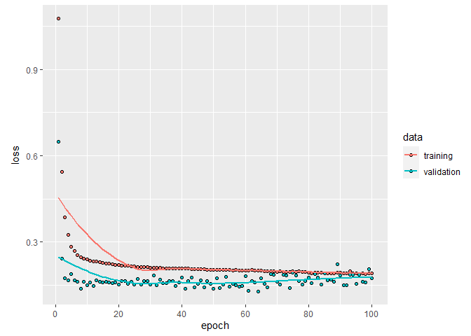

```r
# Plot training history
plot(history)
```

```r
# R2
pred <- predict(my_nn_model, as.matrix(df_data_scaled_no_na[, flux_independent_variables, drop = FALSE]))
```

```
## 134/134 - 1s - 521ms/epoch - 4ms/step
```

```r
r2_ffnn <- cor(df_data_scaled_no_na$y, pred)^2
cat("R2 =", r2_ffnn, "\n")
```

```
## R2 = 0.8172698
```

#### Cross validation

- Perform the same cross validation experiment as with the linear model, and store the cross validation MSE. **Hint**: Make sure to redefine the model with `init_net` at each loop.

```r
train_sitenames_count <- 10
k <- 10 #folds
mse_per_fold_ffnn <- list()

for (i in 1:k){
  test_sitenames <- sample(unique(df_data_scaled_no_na$sitename), train_sitenames_count)
  train_sitenames <- setdiff(unique(df_data_scaled_no_na$sitename), train_sitenames)
  df_train <- df_data_scaled_no_na[df_data_scaled_no_na$sitename %in% train_sitenames, ]
  df_test <- df_data_scaled_no_na[df_data_scaled_no_na$sitename %in% test_sitenames, ]
  start_time <- Sys.time()
  history <- my_nn_model  %>% fit(
  x = as.matrix(df_train[, flux_independent_variables, drop = FALSE]),
  y = df_train$y,
  epochs = 100,
  batch_size = 512,
  validation_split = 0.2,
  verbose = 0
  )
  end_time <- Sys.time()
  ffnn_training_time_cv <- difftime(end_time, start_time, units = "mins")

  # Make predictions on the test set
  pred <- predict(my_nn_model, as.matrix(df_test[, flux_independent_variables, drop = FALSE]))  # Adjust this based on your data

  # Calculate MSE
  mse <- mean((df_test$y - pred)^2, na.rm = TRUE)
  mse_per_fold_ffnn[[i]] <- mse

  cat(paste("Fold", i, "MSE:", mse, "\n"))
}
```

```
## 22/22 - 0s - 85ms/epoch - 4ms/step
## Fold 1 MSE: 0.335587836131744
## 20/20 - 0s - 60ms/epoch - 3ms/step
## Fold 2 MSE: 0.208875217796311
## 20/20 - 0s - 56ms/epoch - 3ms/step
## Fold 3 MSE: 0.546899584626332
## 22/22 - 0s - 59ms/epoch - 3ms/step
## Fold 4 MSE: 0.196833257145734
## 23/23 - 0s - 56ms/epoch - 2ms/step
## Fold 5 MSE: 0.396189781912182
## 20/20 - 0s - 48ms/epoch - 2ms/step
## Fold 6 MSE: 0.130063239272562
## 14/14 - 0s - 41ms/epoch - 3ms/step
## Fold 7 MSE: 0.304303625229943
## 22/22 - 0s - 49ms/epoch - 2ms/step
## Fold 8 MSE: 0.118882057817473
## 22/22 - 0s - 48ms/epoch - 2ms/step
## Fold 9 MSE: 0.42471847822191
## 17/17 - 0s - 42ms/epoch - 2ms/step
## Fold 10 MSE: 0.245675985322334
```

```r
# Calculate the mean MSE across all folds
cv_mse_ffnn <- mean(unlist(mse_per_fold_ffnn), na.rm = TRUE)
cat(paste("\n", "CV MSE (Feedforward Neural Network):", cv_mse_ffnn, "\n"))
```

```
##
##  CV MSE (Feedforward Neural Network): 0.290802906347652
```

### Convolutional neural network

Now, we use the full (cropped) NDVI images and we let a CNN model extract the relevant features. We then feed those features to a feed forward neural network.

```r
# Specify the folder path for NDVI files
ndvi_folder_og <- "./data/ndvi"
ndvi_folder_crop <- "./data/cropped_ndvi"
ndvi_folder_resize <- "./data/resize_ndvi"

# List NDVI files
ndvi_files_og <- list.files(path = ndvi_folder_og, full.names = TRUE)
ndvi_files_crop <- list.files(path = ndvi_folder_crop, full.names = TRUE)
ndvi_files_resize <- list.files(path = ndvi_folder_resize, full.names = TRUE)
```

```r
df_data_scaled$cropped_files <-  ndvi_files_crop
df_data_scaled$resized_files <- ndvi_files_resize

flux_data_filtered$cropped_files  <-  ndvi_files_crop
flux_data_filtered$resized_files  <-  ndvi_files_resize

write.csv(flux_data_filtered, file = 'data/flux_data_filtered.csv', row.names = FALSE)
```

#### Image pre-processing

- Generate a new `data.frame` called `df_data_cnn` that includes 3 rows: `sitename`, `y`, and the location of the corresponding NDVI file, called `ndvi_file`. Make sure that you only store NDVI files which have more than 40% healthy pixels.
- I use the resized images instead of cropped images.

```r
df_data_cnn <- na.omit(df_data_scaled)
dim(df_data_cnn)
```

```
## [1] 4286   13
```

```r
head(df_data_cnn)
```

```
##           y fpar_loess_per_month TA_F_per_month SW_IN_F_per_month
## 1 3.8606854            1.1246504      1.6775735        0.70588811
## 2 3.4284554            1.5694086      1.4626462        0.49319359
## 3 2.1553945            1.6651279      0.9529094       -0.03174441
## 4 0.9771032            1.4938782      0.5216809       -0.73090651
## 5 2.2335244            0.6240253      0.8135603        0.07127218
## 6 2.3130680            1.1789033      0.8432124        0.78781153
##   LW_IN_F_per_month VPD_F_per_month PA_F_per_month P_F_per_month WS_F_per_month
## 1         2.0995609      1.16868470      0.5871184     1.2067286      0.2535646
## 2         1.6412207      0.85626135      0.6129093     2.1857810     -0.1284115
## 3         0.9418546      0.44855518      0.6823343     1.2642986      0.1104574
## 4         0.7238240     -0.13647241      0.6989176     0.5165380     -0.1393783
## 5         0.7329171      0.02205477      0.6542319     1.7032410     -0.1989172
## 6         0.6993275      0.05848741      0.6551889     0.7025843      0.0264536
##   CO2_F_MDS_per_month sitename
```

[output cut: 20 more lines]

Now, it is time to construct the inputs to the CNN. * Create and fill a 3-dimensional array (tensor), with first dimension corresponding to the index of the NDVI file, and second and third dimensions corresponding to the image axes.

```r
dim(matrix(unlist(readRDS(df_data_cnn$resized_files[1])), nrow = 50, ncol = 50, byrow = TRUE))
```

```
## [1] 50 50
```

*Hint:* use `cropped_dim` as previously when you computed the summary statistics.

```r
IMAGE_WIDTH <- 50
IMAGE_HEIGHT <- 50

ndvi_tensor <- array(NA,dim =c(length(df_data_cnn$resized_files), IMAGE_WIDTH, IMAGE_HEIGHT))
for(j in 1:length(df_data_cnn$resized_files)){
  ndvi_tensor[j,,] <- matrix(unlist(readRDS(df_data_cnn$resized_files[j])), nrow = 50, ncol = 50, byrow = TRUE)
}
```

We kindly provide you with a function `preprocess_images` that scales the values of an NDVI tensor and replaces the `NA` in the rasters by interpolated values.

```r
IMAGE_CHANNELS <- 1
IMAGE_SIZE <- c(IMAGE_WIDTH,IMAGE_HEIGHT,IMAGE_CHANNELS)

preprocess_images <- function(ndvi_tensor){

  min_ndvi <- -10000
  max_ndvi <- 10000

  #fill missing values
  #nd <- apply(ndvi_tensor, c(2,3), function(i) na_interpolation(i))
  nd <- ndvi_tensor

  #rescale to [0,1]
  nd <- (nd-min_ndvi)/(max_ndvi-min_ndvi)

  #reshape adding an extra dimension
  array_reshape(nd, dim = c(-1,IMAGE_SIZE))

}
```

- Clean the `ndvi_tensor` with `preprocess_images`

```r
ndvi_tesor <- preprocess_images(ndvi_tensor)
dim(ndvi_tensor)
```

```
## [1] 4286   50   50
```

- Plot one of the image, just to make sure that the pre-processing went smoothly.

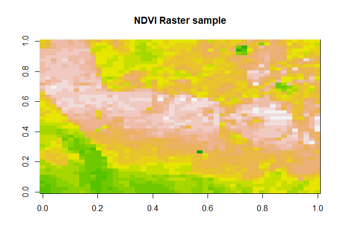

```r
image(ndvi_tensor[6,,], main = "NDVI Raster sample", col = terrain.colors(20))
```

#### Standard fit

Let’s create the CNN.

- Create a function `create_cnn` that returns the CNN model.
  - The cnn takes as input a tensor of shape `IMAGE_SIZE`.
  - It should then be composed of
  - a CNN layer `layer_conv_2d` with `filters = 4, kernel_size = c(5,5), activation = 'relu', padding = 'same'`
  - a `batch_layer`
  - a max pooling layer `layer_max_pooling_2d` with `pool_size = c(10, 10)`
  - a FFNN composed of
    - 1 input layer
    - 1 hidden layer with `units = 32, activation = 'relu'`,
    - 1 hidden layer with `units = 16, activation = 'relu'`, and
    - 1 output layer with `units = 1, activation = 'linear'`.

**Hint:** you may want to flatten the features after the pool layer.

```r
create_cnn <- function() {

  # Define the model
  model <- keras_model_sequential()

  # Add the CNN layer
  model %>%
    layer_conv_2d(filters = 4, kernel_size = c(5, 5), activation = 'relu', padding = 'same', input_shape = c(IMAGE_WIDTH, IMAGE_HEIGHT, 1)) %>%

    # Add batch normalization
    layer_batch_normalization() %>%

    # Add max pooling layer
    layer_max_pooling_2d(pool_size = c(10, 10)) %>%

    # Flatten the features
    layer_flatten() %>%

    # Add the MLP (Multi-Layer Perceptron)
    layer_dense(units = 32, activation = 'relu') %>%
    layer_dense(units = 16, activation = 'relu') %>%
    layer_dense(units = 1, activation = 'linear')

  # Compile the model
  model %>% compile(
    loss = 'mse',
    optimizer = optimizer_adam(lr = 0.01)
  )

  return(model)
}
```

- Create a function `init_cnn` that returns the compiled CNN, with the Adam optimizer and a learning rate `lr=0.01`.

```r
init_cnn <- function() {

  # Initialize the CNN
  cnn_model <- create_cnn()

  # Define optimizer with specified learning rate
  opt <- optimizer_adam(lr = 0.01)

  # Compile the model
  cnn_model %>% compile(
    loss = 'mse',
    optimizer = opt
  )

  return(cnn_model)
}
```

#### Model architecture

- Similarly to the neural network standard fit, perform a standard fit of the CNN with all the features. Use the same training meta parameters as the neural network.
  - Plot the training history.
  - Don’t forget to record the training time!
  - Calculate and store the coefficient of determination R2

**Hint:** This may take a while.

```r
# Initialize and compile CNN model
my_cnn_model <- init_cnn()

# Start training time
start_time <- Sys.time()

# Fit the CNN model
history_cnn <- my_cnn_model %>% fit(
  x = ndvi_tensor,
  y = df_data_cnn$y,
  epochs = 100,
  batch_size = 512,
  validation_split = 0.2,
  verbose = 2
)
```

```
## 7/7 - 5s - loss: 5.4886 - val_loss: 32.8681 - 5s/epoch - 648ms/step
## 7/7 - 3s - loss: 2.2077 - val_loss: 7.5047 - 3s/epoch - 468ms/step
## 7/7 - 3s - loss: 1.5145 - val_loss: 4.7995 - 3s/epoch - 472ms/step
## 7/7 - 3s - loss: 1.1860 - val_loss: 5.0887 - 3s/epoch - 475ms/step
## 7/7 - 3s - loss: 1.0737 - val_loss: 3.8288 - 3s/epoch - 463ms/step
## 7/7 - 3s - loss: 0.9587 - val_loss: 2.7581 - 3s/epoch - 458ms/step
## 7/7 - 3s - loss: 0.9173 - val_loss: 2.3708 - 3s/epoch - 460ms/step
## 7/7 - 3s - loss: 0.8747 - val_loss: 2.3251 - 3s/epoch - 461ms/step
## 7/7 - 3s - loss: 0.8466 - val_loss: 2.2174 - 3s/epoch - 455ms/step
## 7/7 - 3s - loss: 0.8282 - val_loss: 1.9666 - 3s/epoch - 447ms/step
## 7/7 - 3s - loss: 0.8115 - val_loss: 1.7753 - 3s/epoch - 455ms/step
## 7/7 - 3s - loss: 0.7979 - val_loss: 1.6528 - 3s/epoch - 465ms/step
## 7/7 - 3s - loss: 0.7872 - val_loss: 1.6007 - 3s/epoch - 463ms/step
## 7/7 - 3s - loss: 0.7742 - val_loss: 1.5182 - 3s/epoch - 455ms/step
## 7/7 - 3s - loss: 0.7633 - val_loss: 1.4353 - 3s/epoch - 452ms/step
## 7/7 - 3s - loss: 0.7547 - val_loss: 1.3696 - 3s/epoch - 446ms/step
## 7/7 - 3s - loss: 0.7471 - val_loss: 1.3272 - 3s/epoch - 446ms/step
## 7/7 - 3s - loss: 0.7370 - val_loss: 1.2952 - 3s/epoch - 447ms/step
## 7/7 - 3s - loss: 0.7271 - val_loss: 1.2305 - 3s/epoch - 437ms/step
## 7/7 - 3s - loss: 0.7200 - val_loss: 1.2117 - 3s/epoch - 454ms/step
## 7/7 - 3s - loss: 0.7126 - val_loss: 1.1613 - 3s/epoch - 448ms/step
## 7/7 - 3s - loss: 0.7055 - val_loss: 1.1375 - 3s/epoch - 441ms/step
## 7/7 - 3s - loss: 0.7001 - val_loss: 1.0763 - 3s/epoch - 455ms/step
## 7/7 - 3s - loss: 0.6923 - val_loss: 1.0727 - 3s/epoch - 440ms/step
## 7/7 - 3s - loss: 0.6864 - val_loss: 1.0687 - 3s/epoch - 445ms/step
## 7/7 - 3s - loss: 0.6768 - val_loss: 0.9966 - 3s/epoch - 444ms/step
## 7/7 - 3s - loss: 0.6727 - val_loss: 1.0250 - 3s/epoch - 481ms/step
## 7/7 - 7s - loss: 0.6634 - val_loss: 0.9853 - 7s/epoch - 1s/step
## 7/7 - 5s - loss: 0.6579 - val_loss: 0.9577 - 5s/epoch - 733ms/step
## 7/7 - 3s - loss: 0.6528 - val_loss: 0.9459 - 3s/epoch - 468ms/step
## 7/7 - 3s - loss: 0.6480 - val_loss: 0.9154 - 3s/epoch - 496ms/step
## 7/7 - 4s - loss: 0.6418 - val_loss: 0.9048 - 4s/epoch - 524ms/step
## 7/7 - 4s - loss: 0.6387 - val_loss: 0.8844 - 4s/epoch - 515ms/step
## 7/7 - 3s - loss: 0.6354 - val_loss: 0.8783 - 3s/epoch - 470ms/step
## 7/7 - 3s - loss: 0.6269 - val_loss: 0.8507 - 3s/epoch - 460ms/step
## 7/7 - 3s - loss: 0.6226 - val_loss: 0.8589 - 3s/epoch - 469ms/step
## 7/7 - 3s - loss: 0.6212 - val_loss: 0.8103 - 3s/epoch - 475ms/step
## 7/7 - 3s - loss: 0.6156 - val_loss: 0.8253 - 3s/epoch - 444ms/step
## 7/7 - 4s - loss: 0.6142 - val_loss: 0.8053 - 4s/epoch - 565ms/step
## 7/7 - 3s - loss: 0.6087 - val_loss: 0.8060 - 3s/epoch - 472ms/step
```

[output cut: 45 more lines]

```
## 7/7 - 3s - loss: 0.5036 - val_loss: 0.6059 - 3s/epoch - 499ms/step
## 7/7 - 3s - loss: 0.5033 - val_loss: 0.6263 - 3s/epoch - 456ms/step
## 7/7 - 3s - loss: 0.5003 - val_loss: 0.6168 - 3s/epoch - 455ms/step
## 7/7 - 3s - loss: 0.5021 - val_loss: 0.6070 - 3s/epoch - 452ms/step
## 7/7 - 3s - loss: 0.5005 - val_loss: 0.6187 - 3s/epoch - 447ms/step
## 7/7 - 3s - loss: 0.4928 - val_loss: 0.6082 - 3s/epoch - 446ms/step
## 7/7 - 3s - loss: 0.4927 - val_loss: 0.6267 - 3s/epoch - 448ms/step
## 7/7 - 3s - loss: 0.4921 - val_loss: 0.6160 - 3s/epoch - 438ms/step
## 7/7 - 3s - loss: 0.4880 - val_loss: 0.6165 - 3s/epoch - 442ms/step
## 7/7 - 3s - loss: 0.4913 - val_loss: 0.6233 - 3s/epoch - 472ms/step
## 7/7 - 4s - loss: 0.4855 - val_loss: 0.6126 - 4s/epoch - 544ms/step
## 7/7 - 4s - loss: 0.4830 - val_loss: 0.6266 - 4s/epoch - 543ms/step
## 7/7 - 4s - loss: 0.4834 - val_loss: 0.6099 - 4s/epoch - 552ms/step
## 7/7 - 3s - loss: 0.4821 - val_loss: 0.6215 - 3s/epoch - 477ms/step
## 7/7 - 3s - loss: 0.4820 - val_loss: 0.6133 - 3s/epoch - 438ms/step
```

```r
# End training time
end_time <- Sys.time()

# Training time
cnn_training_time <- difftime(end_time, start_time, units = "mins")
cat("CNN training time:", cnn_training_time, "mins\n")
```

```
## CNN training time: 5.574858 mins
```

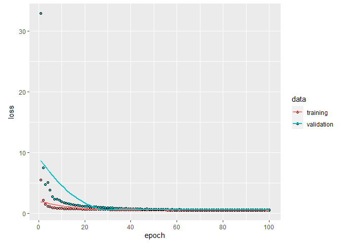

```r
# Plot the training history
plot(history_cnn)
```

```r
# Evaluate R-squared
pred_cnn <- my_cnn_model %>% predict(ndvi_tensor)
```

```
## 134/134 - 1s - 1s/epoch - 10ms/step
```

```r
r2_cnn <- cor(df_data_cnn$y, pred_cnn)^2
cat("R2 (CNN):", r2_cnn, "\n")
```

```
## R2 (CNN): 0.5035579
```

#### Cross validation

The k-fold cross validation procedure involves repeated training of the model considered. Since training the CNN takes a siginificant amout of time, we suggest here to proceed to a **holdout cross validation**:

“*In the holdout method, we randomly assign data points to two sets d0 and d1, usually called the training set and the test set, respectively. The size of each of the sets is arbitrary although typically the test set is smaller than the training set. We then train (build a model) on d0 and test (evaluate its performance) on d1.*” (source: Wikipedia)

- Perform a hold out cross validation of the CNN, where the training dataset consists of 90% of the data. Compute the cross validation MSE.

**Hint: you may want to use the `sample` function**

```r
# Set the proportion for training data
train_proportion <- 0.9

# Generate indices for training and test sets
indices <- sample(1:length(df_data_cnn$resized_files))
train_size <- round(length(indices) * train_proportion)
train_ind <- indices[1:train_size]
test_ind <- indices[(train_size + 1):length(indices)]


# Create training and test tensors
tensor_train <- array_reshape(ndvi_tensor[train_ind,,], dim=c(-1, IMAGE_WIDTH, IMAGE_HEIGHT, 1))
tensor_test <- array_reshape(ndvi_tensor[test_ind,,], dim=c(-1, IMAGE_WIDTH, IMAGE_HEIGHT, 1))


# Initialize and compile CNN model
my_cnn_model <- init_cnn()

# Start training time
start_time <- Sys.time()

# Fit the CNN model on the training data
history_cnn <- my_cnn_model %>% fit(
  x = tensor_train,
  y = df_data_cnn$y[train_ind],
  epochs = 100,
  batch_size = 512,
  validation_split = 0.2,
  verbose = 2
)
```

```
## 7/7 - 4s - loss: 5.5532 - val_loss: 15.8727 - 4s/epoch - 570ms/step
## 7/7 - 3s - loss: 2.0262 - val_loss: 7.5425 - 3s/epoch - 412ms/step
## 7/7 - 3s - loss: 1.6950 - val_loss: 2.8464 - 3s/epoch - 415ms/step
## 7/7 - 3s - loss: 1.2859 - val_loss: 2.3838 - 3s/epoch - 426ms/step
## 7/7 - 3s - loss: 1.2309 - val_loss: 1.8703 - 3s/epoch - 403ms/step
## 7/7 - 3s - loss: 1.1415 - val_loss: 1.4982 - 3s/epoch - 399ms/step
## 7/7 - 3s - loss: 1.0998 - val_loss: 1.3488 - 3s/epoch - 403ms/step
## 7/7 - 3s - loss: 1.0628 - val_loss: 1.3425 - 3s/epoch - 398ms/step
## 7/7 - 3s - loss: 1.0281 - val_loss: 1.2642 - 3s/epoch - 407ms/step
## 7/7 - 3s - loss: 0.9989 - val_loss: 1.2509 - 3s/epoch - 409ms/step
## 7/7 - 3s - loss: 0.9784 - val_loss: 1.2072 - 3s/epoch - 398ms/step
## 7/7 - 3s - loss: 0.9525 - val_loss: 1.1239 - 3s/epoch - 408ms/step
## 7/7 - 3s - loss: 0.9253 - val_loss: 1.1542 - 3s/epoch - 403ms/step
## 7/7 - 3s - loss: 0.9056 - val_loss: 1.1502 - 3s/epoch - 405ms/step
## 7/7 - 3s - loss: 0.8866 - val_loss: 1.1565 - 3s/epoch - 405ms/step
## 7/7 - 3s - loss: 0.8649 - val_loss: 1.0653 - 3s/epoch - 400ms/step
## 7/7 - 3s - loss: 0.8568 - val_loss: 1.0472 - 3s/epoch - 413ms/step
## 7/7 - 3s - loss: 0.8374 - val_loss: 1.1031 - 3s/epoch - 404ms/step
## 7/7 - 3s - loss: 0.8159 - val_loss: 1.0769 - 3s/epoch - 398ms/step
## 7/7 - 3s - loss: 0.7983 - val_loss: 1.1159 - 3s/epoch - 408ms/step
## 7/7 - 3s - loss: 0.7943 - val_loss: 1.1474 - 3s/epoch - 413ms/step
## 7/7 - 3s - loss: 0.7709 - val_loss: 1.0152 - 3s/epoch - 400ms/step
## 7/7 - 3s - loss: 0.7540 - val_loss: 1.0173 - 3s/epoch - 401ms/step
## 7/7 - 3s - loss: 0.7389 - val_loss: 1.0750 - 3s/epoch - 408ms/step
## 7/7 - 3s - loss: 0.7170 - val_loss: 1.0589 - 3s/epoch - 431ms/step
## 7/7 - 3s - loss: 0.7024 - val_loss: 1.0724 - 3s/epoch - 447ms/step
## 7/7 - 3s - loss: 0.6928 - val_loss: 1.0145 - 3s/epoch - 412ms/step
## 7/7 - 3s - loss: 0.6727 - val_loss: 0.9817 - 3s/epoch - 405ms/step
## 7/7 - 3s - loss: 0.6641 - val_loss: 0.9697 - 3s/epoch - 408ms/step
## 7/7 - 3s - loss: 0.6548 - val_loss: 1.0195 - 3s/epoch - 412ms/step
## 7/7 - 3s - loss: 0.6464 - val_loss: 1.0355 - 3s/epoch - 397ms/step
## 7/7 - 3s - loss: 0.6464 - val_loss: 1.1024 - 3s/epoch - 495ms/step
## 7/7 - 3s - loss: 0.6396 - val_loss: 0.9995 - 3s/epoch - 438ms/step
## 7/7 - 3s - loss: 0.6439 - val_loss: 0.9090 - 3s/epoch - 416ms/step
## 7/7 - 3s - loss: 0.6380 - val_loss: 1.0075 - 3s/epoch - 410ms/step
## 7/7 - 3s - loss: 0.6249 - val_loss: 0.9835 - 3s/epoch - 414ms/step
## 7/7 - 3s - loss: 0.6245 - val_loss: 0.9299 - 3s/epoch - 404ms/step
## 7/7 - 3s - loss: 0.6161 - val_loss: 0.9616 - 3s/epoch - 419ms/step
## 7/7 - 3s - loss: 0.6150 - val_loss: 0.8918 - 3s/epoch - 412ms/step
## 7/7 - 3s - loss: 0.6065 - val_loss: 0.8332 - 3s/epoch - 411ms/step
```

[output cut: 45 more lines]

```
## 7/7 - 1s - loss: 0.5111 - val_loss: 0.5990 - 1s/epoch - 213ms/step
## 7/7 - 1s - loss: 0.5110 - val_loss: 0.5984 - 1s/epoch - 213ms/step
## 7/7 - 1s - loss: 0.5180 - val_loss: 0.5868 - 1s/epoch - 214ms/step
## 7/7 - 1s - loss: 0.5142 - val_loss: 0.6323 - 1s/epoch - 211ms/step
## 7/7 - 2s - loss: 0.5265 - val_loss: 0.6510 - 2s/epoch - 225ms/step
## 7/7 - 1s - loss: 0.5037 - val_loss: 0.5796 - 1s/epoch - 214ms/step
## 7/7 - 2s - loss: 0.5109 - val_loss: 0.5951 - 2s/epoch - 215ms/step
## 7/7 - 2s - loss: 0.4989 - val_loss: 0.5984 - 2s/epoch - 216ms/step
## 7/7 - 2s - loss: 0.5018 - val_loss: 0.6186 - 2s/epoch - 221ms/step
## 7/7 - 1s - loss: 0.4970 - val_loss: 0.5763 - 1s/epoch - 212ms/step
## 7/7 - 2s - loss: 0.5000 - val_loss: 0.5856 - 2s/epoch - 217ms/step
## 7/7 - 2s - loss: 0.5049 - val_loss: 0.6068 - 2s/epoch - 215ms/step
## 7/7 - 1s - loss: 0.5019 - val_loss: 0.6268 - 1s/epoch - 214ms/step
## 7/7 - 2s - loss: 0.4885 - val_loss: 0.5849 - 2s/epoch - 214ms/step
## 7/7 - 2s - loss: 0.4898 - val_loss: 0.5757 - 2s/epoch - 217ms/step
```

```r
# End training time
end_time <- Sys.time()

# Training time
cnn_training_time <- difftime(end_time, start_time, units = "mins")
cat("CNN training time:", cnn_training_time, "mins\n")
```

```
## CNN training time: 4.095346 mins
```

```r
# Evaluate on the test set
pred_cnn_test <- my_cnn_model %>% predict(tensor_test)
```

```
## 14/14 - 0s - 192ms/epoch - 14ms/step
```

```r
# Calculate MSE on the test set
mse_cnn <- mean((df_data_cnn$y[test_ind] - pred_cnn_test)^2)
cat(paste("CV MSE (CNN):", mse_cnn, "\n"))
```

```
## CV MSE (CNN): 0.552179055256971
```

### Model selection

After a lot of coding, time to think!

Summarize the statistics of each model (training time, R2 and CV MSE)

```r
cat(paste0("Cross validation MSE Score for Linear Regression Model: ", cv_mse_lm))
```

```
## Cross validation MSE Score for Linear Regression Model: 0.307550865492133
```

```r
cat("\nLM training time", as.numeric(lm_training_time), "mins")
```

```
##
## LM training time 0.0002182484 mins
```

```r
cat(paste0("\n \n Cross validation MSE Score for MLP model: ",cv_mse_ffnn))
```

```
##
##
##  Cross validation MSE Score for MLP model: 0.290802906347652
```

```r
cat("\nFFNN training time", ffnn_training_time, "mins")
```

```
##
## FFNN training time 0.7172185 mins
```

```r
cat(paste0("\n\nCross validation MSE Score for CNN model: ",mse_cnn))
```

```
##
##
## Cross validation MSE Score for CNN model: 0.552179055256971
```

```r
cat("\nCNN training time:", cnn_training_time, "mins\n")
```

```
##
## CNN training time: 4.095346 mins
```

- Based upon the previous table, and on criteria of your own, which model would you pick, if you were to create a global GPP map of the entire Earth system from NDVI data? Provide a clear justification.
- From a trade off perspective it is evident that MLP model performs better that the other both models. I think this comparison based on what is done is not fair. If I concat the NDVI data with the given flux dataset variables and then do the final CNN model, I am not sure by how much these results would vary.

If I were to create a global GPP map, I would go with an lesser loss model, i.e. with low loss, given lack of straight forward model build, it is rather difficult to choose model. Ideally a combination of these models (ensemble) would be a better approach.

- Based upon the previous table, and on criteria of your own, which model would you pick, if you were to better understand how spatial variations in photosynthetic rates relate to GPP? Provide a clear justification. I would prefer the CNN and MLP models together, as an ensemble. Using both numerical data (sensor collection data) and the imagery data(where ever the spatial data is available) must yield better results.